# Emission Driven Hector

# 4 Okay did one of the fluxes really change between the RCPs?

Okay great so the atmospheric CO2 is the same when running with constraints, we do see some difference in the free running which means that there is some change in the carbon cycle based on our changes… which is not surprising…

```r
rbind(read.csv(file.path(BASE_DIR, "data", "hector_comp_v25.csv")),
      read.csv(file.path(BASE_DIR, "data", "hector_comp_v3.csv"))) %>%
  filter(scenario %in% c("rcp26_constrained", "rcp26", "rcp60_constrained", "rcp60", "rcp85_constrained", "rcp85")) ->
  hector_versions
```

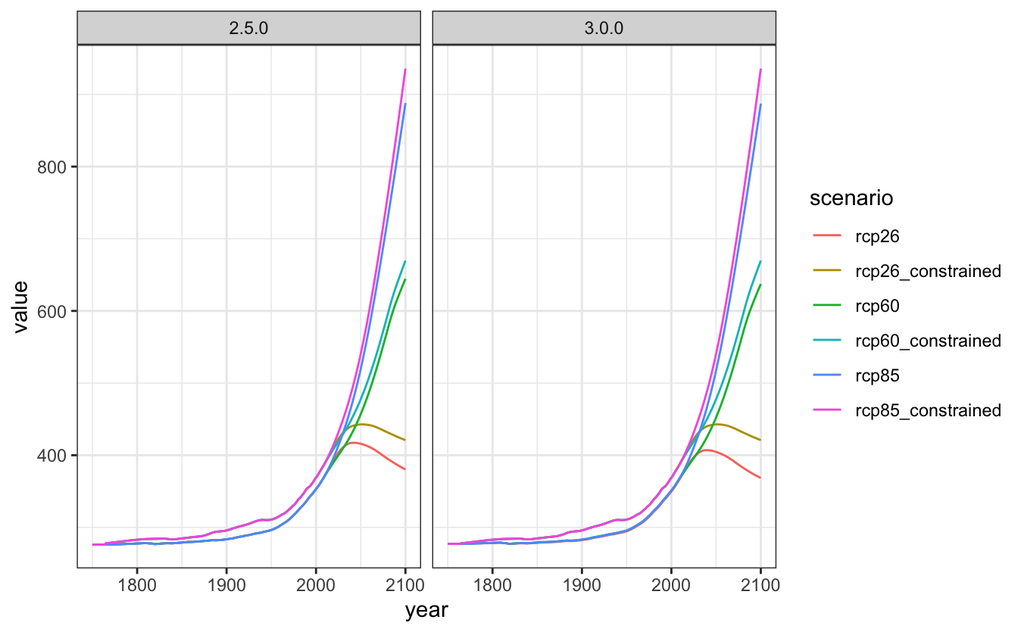

```r
hector_versions %>%
  filter(variable == ATMOSPHERIC_CO2()) %>%
  ggplot(aes(year, value, color = scenario)) +
  geom_line() +
  facet_wrap("version")
```

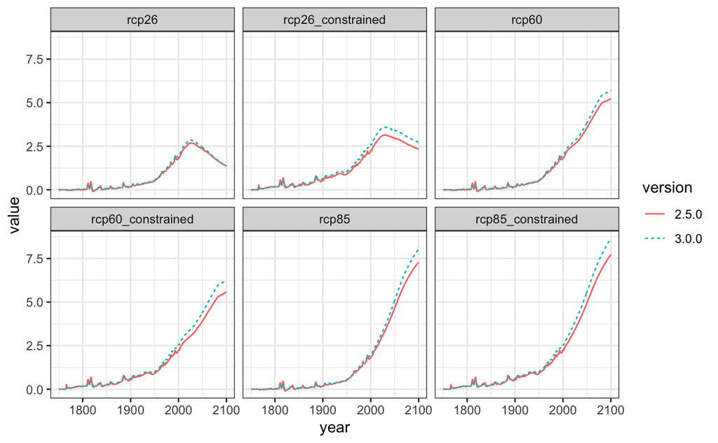

```r
hector_versions %>%
  filter(variable == "atm_ocean_flux") %>%
  ggplot(aes(year, value, color = version, linetype = version)) +
  geom_line() +
  facet_wrap("scenario")
```

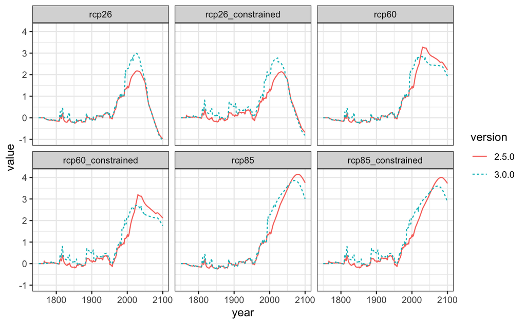

```r
hector_versions %>%
  filter(variable %in% c("atm_land_flux", "NBP")) %>%
  ggplot(aes(year, value, color = version, linetype = version)) +
  geom_line() +
  facet_wrap("scenario")
```

In both versions we see this largish off set between free running Hector & concentration driven Hector so atleast this is not a v3 devlopment that is driving this difference…

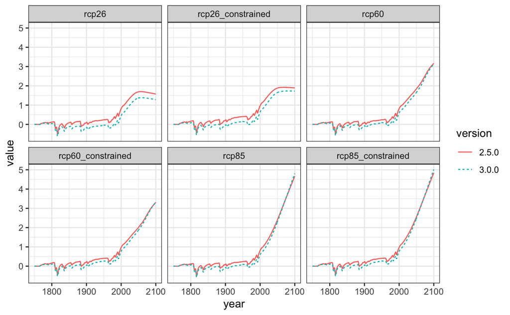

```r
hector_versions %>%
  filter(variable == GLOBAL_TEMP()) %>%
  ggplot(aes(year, value, color = version, linetype = version)) +
  geom_line() +
  facet_wrap("scenario")
```

The ocean sink increased between v 2.5 and v 3

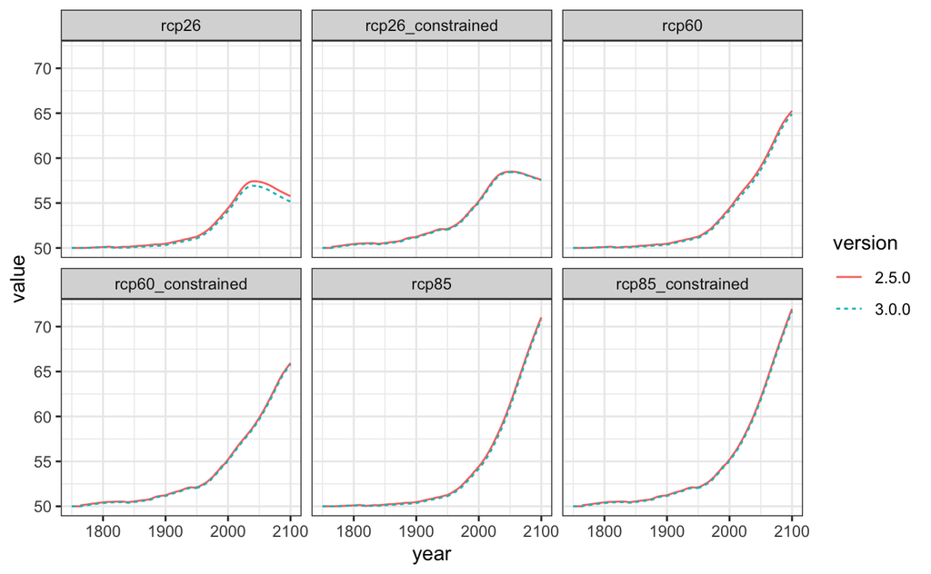

```r
hector_versions %>%
  filter(variable == NPP()) %>%
  ggplot(aes(year, value, color = version, linetype = version)) +
  geom_line() +
  facet_wrap("scenario")
```

```r
hector_versions %>%
  filter(variable %in% c("atm_land_flux", "NBP")) %>%
  ggplot(aes(year, value, color = version, linetype = version)) +
  geom_line() +
  facet_wrap("scenario")
```

[output not shown]

```r
hector_versions %>%
  filter(variable == GLOBAL_TEMP()) %>%
  ggplot(aes(year, value, color = version, linetype = version)) +
  geom_line() +
  facet_wrap("scenario")
```

[output not shown]

```r
hector_versions %>%
  filter(variable == NPP()) %>%
  ggplot(aes(year, value, color = version, linetype = version)) +
  geom_line() +
  facet_wrap("scenario")
```

[output not shown]

```r
hector_versions %>%
  filter(variable == RF_TOTAL()) %>%
  select(scenario, year, variable, value, version) %>%
  spread(version, value) %>%
  mutate(abs_dif = abs(`3.0.0` - `2.5.0`)) %>%
  pull(abs_dif) %>%  summary()
```

```
   Min. 1st Qu.  Median    Mean 3rd Qu.    Max.
 0.0000  0.1666  0.2646  0.2553  0.3365  0.5751
```

How do the aerosol RF values differ from one another?

```r
hector_areosol_RF %>%
  spread(version, value) %>%
  mutate(abs_dif = abs(`3.0.0` - `2.5.0`)) %>%
  pull(abs_dif) %>%  summary()
```

```
   Min. 1st Qu.  Median    Mean 3rd Qu.    Max.
 0.0000  0.2870  0.4017  0.3798  0.5012  0.6624
```

[figure not shown]

[figure not shown]

[figure not shown]

[figure not shown]

```r
var <- "NBP"
hectorv3_driven %>%
  filter(year > 1850) %>%
  filter(variable == var) %>%
  ggplot(aes(year, value, color = scenario, linetype = driven)) +
  geom_line() +
  labs(title = var)
```

```r
var <- "atm_ocean_flux"
hectorv3_driven %>%
  filter(year > 1850) %>%
  filter(variable == var) %>%
  ggplot(aes(year, value, color = scenario, linetype = driven)) +
  geom_line() +
  labs(title = var)
```

```r
hector_versions %>%
  filter(version == "3.0.0") %>%
  filter(variable == OCEAN_CFLUX()) %>%
  ggplot(aes(year, value, color = scenario)) +
  geom_line()
```